# Node Level Summaries

These techniques aim at indentifying which nodes are most central to the network and in what ways.

#### Node degree

##### In-Degree

This measure can be used to assess the “popularity” of the node since it counst all the direct ties that end in this node.

```r
### Housekeeping ###
library(statnet)
#create matrix
socio<-matrix(c(0,1,0,0,0,1,0,0,0,0,1,1,0,1,0,0,1,1,0,0,0,0,0,1,0),5,5,T)
rownames(socio)<-colnames(socio)<-c("Ahmed","Sofia","Berthold","Carlo",
"Niamh")
#make it a network object
net3<-network(socio)
```

```r
#calculate in-degree
#remind ourselves of the names assigned to the vertices.
net3 %v% "vertex.names"
```

```
[1] "Ahmed"    "Sofia"    "Berthold" "Carlo"    "Niamh"
```

```r
degree(net3, cmode = "indegree")
```

```
[1] 2 3 1 2 0
```

##### Out-Degree

Out-Degree measures outgoingness since it is the number of ties that originate fromm this node.

We can measure in-degree and out-degree only when we have a directed graph.

```r
degree(net3, cmode = "outdegree")
```

```
[1] 1 1 3 2 1
```

##### Degree

When we have an undirected graph, we meanusre degree as the number of edges connected to a node.

```r
degree(net3, cmode = "freeman")
```

```
[1] 3 4 4 4 1
```

#### Centrality

Centrality doest not refer to the absolute position of a node in a network, since different visualization methods place nodes in different positions. Measures of Centrality are discussed in the following sections.

##### Closeness Centrality

Closeness centrality measures how close each node is to all other nodes in the graph. To do so, we take the inverse if the sum of path lenghts to all other nodes to give a measure of each node’s importance in this respect.

** 1/ distance[ v(i), v(j)] **

This number is large for nodes that are clse to many other nodes and small for nodes that aren’t.

```r
closeness(net3, gmode = "digraph")
```

```
[1] 0.0 0.0 0.0 0.0 0.5
```

```r
#we use "dgraph" for directed graphs and "graph" for undirected graphs.
```

##### Betweenness Centrality

Betweeness measures how important a node is to get to other nodes. The most common method to measure betweenness is by summing across all pairs of nodes the ratio of the number of geodesics between pairs of nodes where the geodesic includes the node of interest Vs the geodesic without it.

```r
betweenness(net3, cmode = "directed")
```

```
[1] 0 1 1 3 0
```

##### Eigenvector Centrality

Eigenvector centrality is calculated by using the values of the first eigenvector of the graph adjacency matrix. Vertices with higher eigenvectors centralities are those which are connected to many other vertices which are, in turn, connected to many others, and so on.

```r
evcent(net3)
```

```
Maximum iterations exceeded in evcent_R without convergence.  This matrix may be pathological - increase maxiter or try eigen().
```

```
[1] 3.848993e-06 3.848993e-06 5.773528e-01 5.773528e-01 5.773451e-01
```

##### Other Measures of Centrality and plotting

There are several other measures of centrality which emphasize different kids of centrality however are all highly positively correlated with one another.

Calculated centrality can be measured the gplot() comand.

Example:

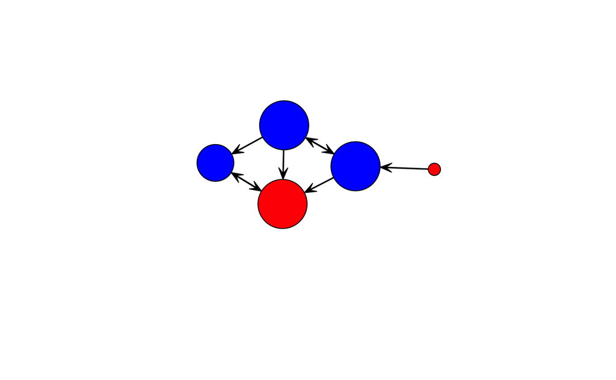

```r
deg<- degree(net3)
#Plot nodes with volume proportion depending on degree
gplot(net3, vertex.cex = deg, vertex.col = c(4,2,4,4,2))
```

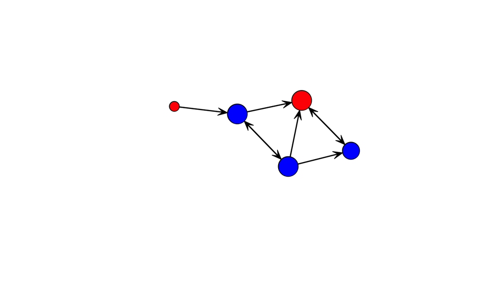

```r
#Plot nodes with volume proportional to the square root of the degree
gplot(net3, vertex.cex = sqrt(deg), vertex.col = c(4,2,4,4,2))
```

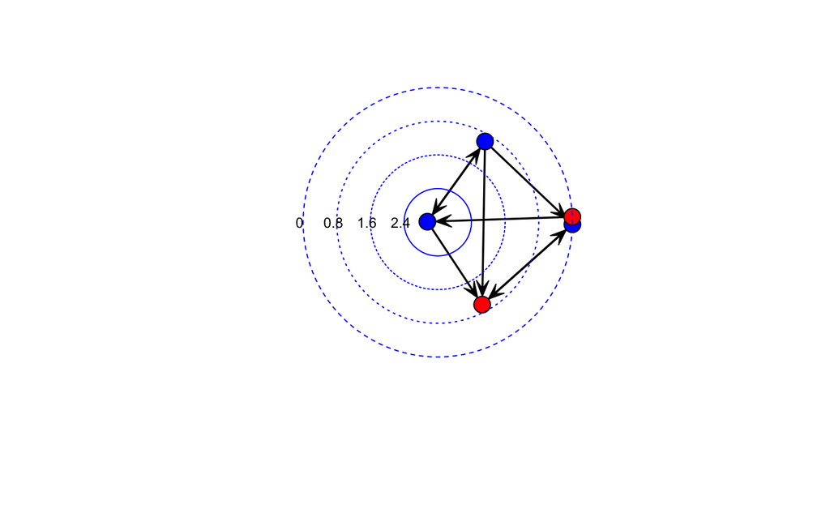

```r
#Place nodes on concentric rings
gplot.target(net3, betweenness(net3), vertex.col=c(4,2,4,4,2), circ.rad = c(1:4)/4)
```

##### Large Graphs

When we have graphs with a high nunber of nodes, we can use the summary command to get five-number summary which gives us a good idea of what is going on. We can also look at a histogram of the number of each measure. We can use the sort() function to understand which nodes are most central without having to go through the whole list.

```r
#decreasing list of outdegrees and a list of the index of the nodes.
sort(degree(net3, cmode = "outdegree"), decreasing = T, index.return= T)
```

```
$x
[1] 3 2 1 1 1

$ix
[1] 3 4 1 2 5
```

#### Cutpoints

A cutpoint is node that, if removed, will split a formerly connected graph into more than one component. When we remove a cutpoint node, many paths between pairs of nodes will no longer exist.

The command to identify cutpoints is ** cutpoints()** from ** statnet**

```r
cutpoints(net3, connected = "weak")
```

```
[1] 4
```

```r
cutpoints(net3, connected = "strong")
```

```
integer(0)
```